# Final Puerto Rican Youth (Grades 7-12) Substance Use Manuscript Code

#### c3. Overall model fit and significance for null and alternative models using `broom::glance()`:

```r
clm_fit_stats <- rbind("clm_model" = glance(clm_with_interaction),
                       "null_model" = glance(null_clm)) %>%
         clean_names()

# Return output:
clm_fit_stats
```

```
## # A tibble: 2 × 6
##     edf    aic    bic log_lik    df_residual  nobs
## * <int>  <dbl>  <dbl> <logLik>         <dbl> <dbl>
## 1    12 18600. 18702.  -9287.899       36473 36485
## 2     2 20605. 20622. -10300.728       36483 36485
```

#### c4. Figure 1: Likelihood vs. Odds

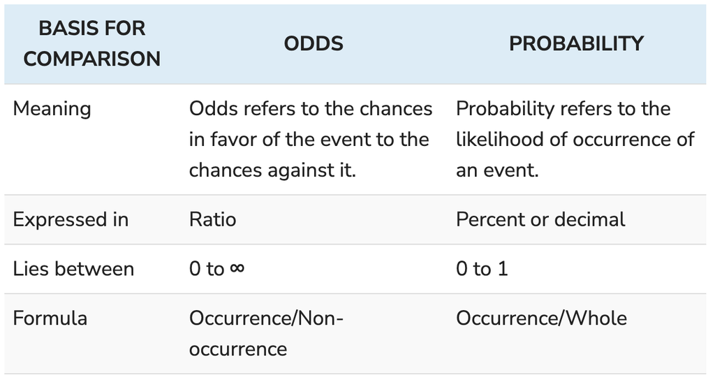

Probabilities vs. Odds

[Citation](https://keydifferences.com/difference-between-odds-and-probability.html)

#### c5. Looking at results as odds ratios with confidence intervals instead of log likelihood

```r
forOdds_clm_with_interaction <- polr(substanceUse ~  q20 + q21 + q22 +
                              ptsd_symptom_total + grade + gender +
                              gender*ptsd_symptom_total + gender*q20 +
                              gender*q21 + gender*q22,
                            data = ordinalRegres_substanceUse,
                            Hess = TRUE)

odds_ratio_clm <- exp(cbind(OR = coef(forOdds_clm_with_interaction),
                            confint(forOdds_clm_with_interaction)))

odds_ratio_clm
```

```
##                                        OR     2.5 %    97.5 %
## q20                             0.4211936 0.3420139 0.5214229
## q21                             1.3139351 1.1007225 1.5763654
## q22                             0.7851751 0.6946401 0.8873982
## ptsd_symptom_total              1.0900014 1.0817558 1.0982893
## grade                           1.4736993 1.4337916 1.5151337
## genderFemale                    0.8225751 0.5789510 1.1668733
## ptsd_symptom_total:genderFemale 0.9855402 0.9752726 0.9959141
## q20:genderFemale                0.9768209 0.7254559 1.3154616
## q21:genderFemale                0.9664859 0.7340019 1.2755142
## q22:genderFemale                0.9517146 0.7973783 1.1361216
```

#### c7. Interpretation of odds ratios

- For students that endorsed having **social support from an adult at home**, the odds of endorsing high substance use decrease by a factor of approximately 0.42.
- For students that endorsed having **social support from at least one peer**, the odds of endorsing high substance use increased by a factor of approximately 1.31,
- For students that endorsed having **social support from a counselor or teacher at school**, the odds of endorsing high substance use decreased by a factor of approximately 0.79.
- For each one unit increase in **PTSD Symptom Total**, the odds of a student endorsing high substance use increased by a factor of approximately 1.09.
- For each increase in **Grade level**, the odds of endorsing high substance use increased by a factor of approximately 1.47,
- Lastly, an interaction was evidenced, such that if a student was **female and experiencing ptsd symptoms**, the odds of endorsing high substance use decreased by a factor of approximately 0.99 when compared to males experiencing ptsd symptoms.
- Please note: The odds ratios for the intercepts are generally not interpreted.